# Principios y Prácticas de SEM y MLM (5ed)

Tema 1.1 Introducción a los Modelos de Ecuaciones Estructurales

Author

Efraín García Sánchez

Published

August 5, 2026

# Práctica

## Conocer nuestra base de datos

#### Base de datos: [“Health and Wellbeing Student Survey”](https://pure.northampton.ac.uk/en/datasets/dataset-for-health-and-wellbeing-student-survey/)

- Encuesta a **590 estudiantes universitarios**
- Cada fila representa **un/a estudiante**
- Cada columna representa **una variable del cuestionario**

#### Bloques principales

- Características sociodemográficas
- Salud física y mental
- Sueño y conexión social
- Actividad física
- Alimentación
- Cafeína, alcohol y nicotina
- Cambios de hábitos desde la llegada a la universidad

[figure not shown]

Northampton student health and wellbeing survey

Fuente: [Roberts et al. (2024)](https://www.tandfonline.com/doi/full/10.1080/09581596.2024.2338182)

## Codebook (Ver el libro de códigos para toda la información) `../data/northampton_student_health_codebook.csv`

```r
# 1. Características sociodemográficas
age_group
gender
sexual_orientation
ethnicity
study_mode
study_level
living_situation

# 2. Salud y bienestar general
phys_health
ment_health
social_connect
sleep_quality
sitting_weekday_hours

# 3. Actividad física
pa_importance
pa_guideline_awareness
pa_guideline_confidence
pa_activity_level
pa_resistance_days
pa_barriers
pa_changed_uni
pa_change_direction

# 4. Alimentación
eat_fruit
eat_vegetables
eat_calcium
eat_white_meat
eat_red_meat
eat_processed_meat
eat_seafood
eat_legumes
eat_sweets
eat_fast_food
eat_convenience_food
eat_home_cooked
eat_breakfast
eat_snacks

# 5. Barreras para consumir saludablement
eat_motivation
eat_affordability
eat_barriers

# 6. Consumo de sustancias y cambio de hábitos
nicotine_freq
caffeine_non_exam
caffeine_exam
alcohol_freq
alcohol_binge_freq
diet_changed_uni
diet_change_direction
```

## Preparar el ambiente de trabajo

```r
# Instalar paquetes
# install.packages("tidyverse")
# install.packages("easystats")
# install.packages("haven")
# install.packages("psych")
# install.packages("sjmisc")
# install.packages("here")
# install.packages("GGally)

# Cargar paquetes
library(tidyverse)
library(easystats)
library(haven)
library(psych)
library(sjmisc)
library(here)
library(GGally)
```

## Preparar el directorio de trabajo (“working directory”)

```r
here::here()
```

```
[1] "/Users/egarcias/Library/CloudStorage/GoogleDrive-egarcias@go.ugr.es/My Drive/codex/SEM_MLM_2026"
```

```r
# "the path root is implicitly set to "the path to the top-level of my current project"
```

- Abrir siempre el archivo `.Rproj`
- No mas `setwd()` o direcciones completas o parciales en los reportes
- Usar `here()` cada vez que lean o guarden archivos.

```r
here("datos", "archivo.csv")
read_csv("datos/northampton_student_health_raw_labels.csv") # ruta parcial
here("imagenes","logos",  "figura.png") # subcarpetas
```

## Importar la base de datos (usando `here`)

```r
# datos *numéricos*: bueno para todo; pero no es intuitivo
data_num <- readr::read_csv(
  here::here("data",
             "northampton_student_health_data_package",
             "northampton_student_health_numeric.csv"))

# datos *categóricos*: bueno para tablas; pero no para análisis estadísticos
data_lab <- readr::read_csv(
  here::here("data",
             "northampton_student_health_data_package",
             "northampton_student_health_raw_labels.csv"))

# datos *etiquetados* (numéricos + etiquetas): bueno para todo, pero no es compatible con algunos paquetes
data <- haven::read_sav(
  here::here("data",
             "northampton_student_health_data_package",
             "northampton_student_health_labelled.sav"))
```

## Importar la base de datos (usando rutas específicas)

```r
# datos *numéricos*: bueno para todo; pero no es intuitivo
data_num <- read_csv("../data/northampton_student_health_data_package/northampton_student_health_numeric.csv")

# datos *categóricos*: bueno para tablas; pero no para análisis estadísticos
data_lab <- read_csv("../data/northampton_student_health_data_package/northampton_student_health_raw_labels.csv")

# datos *etiquetados* (numéricos + etiquetas): bueno para todo, pero no es compatible con algunos paquetes
data <- haven::read_sav("../data/northampton_student_health_data_package/northampton_student_health_labelled.sav")
```

## Ver la base de datos: `data_num` (numéricos)

```r
head(data_num)
```

| id | age_group | gender | sexual_orientation | ethnicity | study_mode | study_level | living_situation | phys_health | ment_health | social_connect | sitting_weekday_hours | sleep_quality | nicotine_freq | pa_importance | pa_guideline_awareness | pa_guideline_confidence | pa_activity_level | pa_resistance_days | pa_barriers | pa_changed_uni | pa_change_direction | eat_fruit | eat_vegetables | eat_calcium | eat_white_meat | eat_red_meat | eat_processed_meat | eat_seafood | eat_legumes | … |
| --- | --- | --- | --- | --- | --- | --- | --- | --- | --- | --- | --- | --- | --- | --- | --- | --- | --- | --- | --- | --- | --- | --- | --- | --- | --- | --- | --- | --- | --- | --- |
| 1 | 1 | 2 | 1 | 1 | 1 | 3 | 1 | 3 | 4 | 4 | 8 | 8 | 0 | 5 | 1 | 3 | 0 | 0 | 1 | 1 | -1 | 4 | 3 | 4 | 2 | 2 | 1 | 1 | 1 | … |
| 2 | 1 | 1 | 2 | 1 | 1 | 3 | 2 | 4 | 3 | 3 | 5 | 7 | 0 | 5 | 1 | 3 | 2 | 4 | 0 | 1 | 1 | 2 | 2 | 3 | 4 | 1 | 6 | 0 | 0 | … |
| 3 | 1 | 1 | 1 | 1 | 1 | 3 | 1 | 4 | 2 | 1 | 7 | 4 | 0 | 3 | 1 | 2 | 1 | 4 | 1 | 0 | NA | 6 | 5 | 6 | 3 | 0 | 0 | 3 | 3 | … |
| 4 | 1 | 1 | 3 | 2 | 1 | 3 | 3 | 3 | 4 | 1 | 9 | 7 | 0 | 3 | 0 | NA | 2 | 1 | 1 | 1 | -1 | 4 | 3 | 2 | 3 | 3 | 1 | 1 | 0 | … |
| 5 | 1 | 1 | 1 | 1 | 1 | 2 | 2 | 4 | 3 | 2 | NA | 2 | 2 | 3 | 0 | NA | 2 | 0 | 1 | 1 | -1 | 4 | 4 | 6 | 3 | 2 | 1 | 1 | 0 | … |
| 6 | 1 | 2 | 1 | 3 | 1 | 6 | 4 | 5 | 3 | 3 | 5 | 5 | 0 | 5 | 0 | NA | 1 | 1 | 1 | 1 | 0 | 1 | 1 | 3 | 2 | 2 | 2 | 1 | 1 | … |

## Ver la base de datos: `data_lab` (categóricos)

```r
head(data_lab)
```

| id | age_group | gender | sexual_orientation | ethnicity | study_mode | study_level | living_situation | phys_health | ment_health | social_connect | sitting_weekday_hours | sleep_quality | nicotine_freq | pa_importance | pa_guideline_awareness | pa_guideline_confidence | pa_activity_level | pa_resistance_days | pa_barriers | pa_changed_uni | pa_change_direction | food_purchase_raw | food_prepare_raw | eat_fruit | eat_vegetables | eat_calcium | eat_white_meat | eat_red_meat | eat_processed_meat | … |
| --- | --- | --- | --- | --- | --- | --- | --- | --- | --- | --- | --- | --- | --- | --- | --- | --- | --- | --- | --- | --- | --- | --- | --- | --- | --- | --- | --- | --- | --- | --- |
| 1 | 18-24 | Male | Heterosexual or Straight | White | Full-time | Level 6 (UG Third Year) | Living at home with parents or caregivers | Fair | Good | Agree | 8 | 8 | Never | Strongly agree | Yes | Neutral | inactive | 0 days | Yes | Yes | The change has been overall negative | Parent or caregiver; | Parent or caregiver; | 1-2 per day | 5-6 per week | 5-6 times per week | 1-2 times per week | 1-2 times per week | Less than once per week | … |
| 2 | 18-24 | Female | Gay or Lesbian | White | Full-time | Level 6 (UG Third Year) | Living in private accommodation in Northampton | Good | Fair | Neutral | 5 | 7 | Never | Strongly agree | Yes | Neutral | active | 4 days | No | Yes | The change has been overall positive | Myself; | Myself; | 3-4 per week | 3-4 per week | 3-4 times per week | 5-6 times per week | Less than once per week | 1-2 times per day | … |
| 3 | 18-24 | Female | Heterosexual or Straight | White | Full-time | Level 6 (UG Third Year) | Living at home with parents or caregivers | Good | Poor | Strongly disagree | 7 | 4 | Never | Neutral | Yes | Somewhat not confident | fairly active | 4 days | Yes | No | NA | Parent or caregiver; | Myself; | 5 or more per day | 3-4 per day | 1-2 times per day | 3-4 times per week | Never | Never | … |
| 4 | 18-24 | Female | Bisexual | Mixed or Multiple | Full-time | Level 6 (UG Third Year) | Living in private accommodation outside of Northampton | Fair | Good | Strongly disagree | 9 | 7 | Never | Neutral | No | NA | active | 1 day | Yes | Yes | The change has been overall negative | Myself;Partner; | Myself;Partner; | 1-2 per day | 5-6 per week | 1-2 times per week | 3-4 times per week | 3-4 times per week | Less than once per week | … |
| 5 | 18-24 | Female | Heterosexual or Straight | White | Full-time | Level 5 (UG Second Year) | Living in private accommodation in Northampton | Good | Fair | Disagree | NA | 2 | 1-2 times per week | Neutral | No | NA | active | 0 days | Yes | Yes | The change has been overall negative | Myself; | Myself; | 1-2 per day | 1-2 per day | 1-2 times per day | 3-4 times per week | 1-2 times per week | Less than once per week | … |
| 6 | 18-24 | Male | Heterosexual or Straight | Black, Black British, Black Welsh, Caribbean or African | Full-time | Other | Living in university managed accommodation | Very good | Fair | Neutral | 5 | 5 | Never | Strongly agree | No | NA | fairly active | 1 day | Yes | Yes | The change has been neither positive nor negative | Myself; | Myself; | 1-2 per week | 1-2 per week | 3-4 times per week | 1-2 times per week | 1-2 times per week | 1-2 times per week | … |

## Ver la base de datos: `data` (numéricos + etiquetas)

```r
head(data)
```

| id | age_group | gender | sexual_orientation | ethnicity | study_mode | study_level | living_situation | phys_health | ment_health | social_connect | sitting_weekday_hours | sleep_quality | nicotine_freq | pa_importance | pa_guideline_awareness | pa_guideline_confidence | pa_activity_level | pa_resistance_days | pa_barriers | pa_changed_uni | pa_change_direction | eat_fruit | eat_vegetables | eat_calcium | eat_white_meat | eat_red_meat | eat_processed_meat | eat_seafood | eat_legumes | … |
| --- | --- | --- | --- | --- | --- | --- | --- | --- | --- | --- | --- | --- | --- | --- | --- | --- | --- | --- | --- | --- | --- | --- | --- | --- | --- | --- | --- | --- | --- | --- |
| 1 | 1 | 2 | 1 | 1 | 1 | 3 | 1 | 3 | 4 | 4 | 8 | 8 | 0 | 5 | 1 | 3 | 0 | 0 | 1 | 1 | -1 | 4 | 3 | 4 | 2 | 2 | 1 | 1 | 1 | … |
| 2 | 1 | 1 | 2 | 1 | 1 | 3 | 2 | 4 | 3 | 3 | 5 | 7 | 0 | 5 | 1 | 3 | 2 | 4 | 0 | 1 | 1 | 2 | 2 | 3 | 4 | 1 | 6 | 0 | 0 | … |
| 3 | 1 | 1 | 1 | 1 | 1 | 3 | 1 | 4 | 2 | 1 | 7 | 4 | 0 | 3 | 1 | 2 | 1 | 4 | 1 | 0 | NA | 6 | 5 | 6 | 3 | 0 | 0 | 3 | 3 | … |
| 4 | 1 | 1 | 3 | 2 | 1 | 3 | 3 | 3 | 4 | 1 | 9 | 7 | 0 | 3 | 0 | NA | 2 | 1 | 1 | 1 | -1 | 4 | 3 | 2 | 3 | 3 | 1 | 1 | 0 | … |
| 5 | 1 | 1 | 1 | 1 | 1 | 2 | 2 | 4 | 3 | 2 | NA | 2 | 2 | 3 | 0 | NA | 2 | 0 | 1 | 1 | -1 | 4 | 4 | 6 | 3 | 2 | 1 | 1 | 0 | … |
| 6 | 1 | 2 | 1 | 3 | 1 | 6 | 4 | 5 | 3 | 3 | 5 | 5 | 0 | 5 | 0 | NA | 1 | 1 | 1 | 1 | 0 | 1 | 1 | 3 | 2 | 2 | 2 | 1 | 1 | … |

## Las variables

```r
names(data)
```

```
 [1] "id"                             "age_group"
 [3] "gender"                         "sexual_orientation"
 [5] "ethnicity"                      "study_mode"
 [7] "study_level"                    "living_situation"
 [9] "phys_health"                    "ment_health"
[11] "social_connect"                 "sitting_weekday_hours"
[13] "sleep_quality"                  "nicotine_freq"
[15] "pa_importance"                  "pa_guideline_awareness"
[17] "pa_guideline_confidence"        "pa_activity_level"
[19] "pa_resistance_days"             "pa_barriers"
[21] "pa_changed_uni"                 "pa_change_direction"
[23] "eat_fruit"                      "eat_vegetables"
[25] "eat_calcium"                    "eat_white_meat"
[27] "eat_red_meat"                   "eat_processed_meat"
[29] "eat_seafood"                    "eat_legumes"
```

[output cut: 16 more lines]

## La estructura de la base de datos

```r
dplyr::glimpse(data)
```

```
Rows: 590
Columns: 61
$ id                             <dbl> 1, 2, 3, 4, 5, 6, 7, 8, 9, 10, 11, 12, …
$ age_group                      <dbl+lbl> 1, 1, 1, 1, 1, 1, 2, 4, 1, 1, 1, 1,…
$ gender                         <dbl+lbl> 2, 1, 1, 1, 1, 2, 1, 1, 2, 2, 2, 2,…
$ sexual_orientation             <dbl+lbl> 1, 2, 1, 3, 1, 1, 1, 1, 1, 1, 1, 1,…
$ ethnicity                      <dbl+lbl> 1, 1, 1, 2, 1, 3, 1, 1, 1, 3, 1, 1,…
$ study_mode                     <dbl+lbl> 1, 1, 1, 1, 1, 1, 1, 2, 1, 1, 1, 1,…
$ study_level                    <dbl+lbl> 3, 3, 3, 3, 2, 6, 4, 3, 1, 2, 1, 1,…
$ living_situation               <dbl+lbl> 1, 2, 1, 3, 2, 4, 3, 3, 1, 2, 4, 1,…
$ phys_health                    <dbl+lbl> 3, 4, 4, 3, 4, 5, 5, 1, 4, 4, 4, 5,…
$ ment_health                    <dbl+lbl> 4, 3, 2, 4, 3, 3, 2, 1, 4, 4, 3, 5,…
$ social_connect                 <dbl+lbl> 4, 3, 1, 1, 2, 3, 2, 4, 4, 3, 3, 3,…
$ sitting_weekday_hours          <dbl> 8, 5, 7, 9, NA, 5, 11, 13, 6, 5, 12, 6,…
$ sleep_quality                  <dbl> 8, 7, 4, 7, 2, 5, 3, 8, 7, 2, 9, 7, 3, …
```

[output cut: 48 more lines]

## Seleccionar algunas variables para examinar

```r
data_small <- data |>
  dplyr::select(
    age_group,
    ethnicity,
    phys_health,
    ment_health,
    sleep_quality,
    social_connect
  )
```

## Revisar la frecuencia de algunos grupos

```r
data_small |>
  count(age_group)
```

| age_group | n |
| --- | --- |
| 1 | 292 |
| 2 | 199 |
| 3 | 65 |
| 4 | 29 |
| 5 | 4 |
| 6 | 1 |

## Revisar la frecuencia de variables `sjmisc::frq`

```r
data_small |>
  dplyr::select(ethnicity) |>
  sjmisc::frq()
```

```
Which one of the following best describes your ethnic group or background? (ethnicity) <numeric>
# total N=590 valid N=590 mean=2.65 sd=1.68

Value |                                                   Label |   N | Raw %
-----------------------------------------------------------------------------
    1 |                                                   White | 230 | 38.98
    2 |                                       Mixed or Multiple |   8 |  1.36
    3 | Black, Black British, Black Welsh, Caribbean or African | 158 | 26.78
    4 |                       Asian, Asian British, Asian Welsh | 182 | 30.85
    5 |                                           White British |   1 |  0.17
    6 |                                        Srilankan/Indian |   1 |  0.17
    8 |                                                 IRANIAN |   1 |  0.17
    9 |                                                  Latino |   1 |  0.17
   10 |                                       Prefer not to say |   1 |  0.17
   11 |                                                  indian |   5 |  0.85
```

[output cut: 19 more lines]

## Revisar descriptivos `psych::describe()`

```r
data_small |>
  psych::describe()
```

|  | vars | n | mean | sd | median | trimmed | mad | min | max | range | skew | kurtosis | se |
| --- | --- | --- | --- | --- | --- | --- | --- | --- | --- | --- | --- | --- | --- |
| age_group | 1 | 590 | 1.740678 | 0.9077330 | 2 | 1.591102 | 1.4826 | 1 | 6 | 5 | 1.2800004 | 1.4646418 | 0.03737078 |
| ethnicity | 2 | 590 | 2.654237 | 1.6805410 | 3 | 2.544492 | 1.4826 | 1 | 13 | 12 | 1.8183558 | 7.8735837 | 0.06918678 |
| phys_health | 3 | 590 | 3.867797 | 0.8737719 | 4 | 3.938559 | 1.4826 | 1 | 5 | 4 | -0.6714717 | 0.3407171 | 0.03597262 |
| ment_health | 4 | 590 | 3.447458 | 1.0536308 | 4 | 3.491525 | 1.4826 | 1 | 5 | 4 | -0.3834130 | -0.4028624 | 0.04337729 |
| sleep_quality | 5 | 590 | 6.230508 | 2.0163385 | 6 | 6.269068 | 2.9652 | 1 | 10 | 9 | -0.1917015 | -0.5320822 | 0.08301134 |
| social_connect | 6 | 590 | 3.310169 | 1.0010512 | 3 | 3.315678 | 1.4826 | 1 | 5 | 4 | -0.2632839 | -0.3836163 | 0.04121263 |

## Revisar descriptivos por grupo `psych::describeBy()`

```r
data_small |>
  dplyr::filter(ethnicity %in% c(1,3, 4)) |>
  psych::describeBy(group = "ethnicity")
```

```
 Descriptive statistics by group
ethnicity: 1
               vars   n mean   sd median trimmed  mad min max range  skew
age_group         1 230 1.53 0.94      1    1.31 0.00   1   5     4  1.77
ethnicity         2 230 1.00 0.00      1    1.00 0.00   1   1     0   NaN
phys_health       3 230 3.67 0.89      4    3.72 1.48   1   5     4 -0.56
ment_health       4 230 3.03 1.03      3    3.03 1.48   1   5     4  0.00
sleep_quality     5 230 5.77 1.93      6    5.78 2.97   1  10     9 -0.03
social_connect    6 230 2.98 0.99      3    3.03 1.48   1   5     4 -0.21
               kurtosis   se
age_group          2.17 0.06
ethnicity           NaN 0.00
phys_health        0.06 0.06
ment_health       -0.55 0.07
sleep_quality     -0.74 0.13
social_connect    -0.56 0.07
------------------------------------------------------------
ethnicity: 3
               vars   n mean   sd median trimmed  mad min max range  skew
age_group         1 158 2.16 0.97      2    2.07 1.48   1   5     4  0.54
ethnicity         2 158 3.00 0.00      3    3.00 0.00   3   3     0   NaN
phys_health       3 158 4.11 0.79      4    4.19 1.48   1   5     4 -0.82
ment_health       4 158 3.79 0.97      4    3.89 1.48   1   5     4 -0.78
sleep_quality     5 158 6.04 2.00      6    6.07 1.48   1  10     9 -0.18
social_connect    6 158 3.47 0.97      3    3.49 1.48   1   5     4 -0.18
               kurtosis   se
age_group         -0.31 0.08
ethnicity           NaN 0.00
phys_health        0.92 0.06
ment_health        0.48 0.08
sleep_quality     -0.33 0.16
social_connect    -0.50 0.08
------------------------------------------------------------
ethnicity: 4
               vars   n mean   sd median trimmed  mad min max range  skew
age_group         1 182 1.64 0.58      2    1.61 0.00   1   3     2  0.26
ethnicity         2 182 4.00 0.00      4    4.00 0.00   4   4     0   NaN
phys_health       3 182 3.93 0.84      4    3.99 1.48   1   5     4 -0.59
ment_health       4 182 3.73 0.91      4    3.77 1.48   1   5     4 -0.46
sleep_quality     5 182 7.02 1.87      7    7.08 1.48   1  10     9 -0.43
social_connect    6 182 3.60 0.92      4    3.64 1.48   1   5     4 -0.29
               kurtosis   se
age_group         -0.72 0.04
ethnicity           NaN 0.00
phys_health        0.15 0.06
ment_health        0.06 0.07
sleep_quality     -0.12 0.14
social_connect    -0.37 0.07
```

## Resumir resultados por grupo `group_by()` y `summarize()`

```r
data_small |>
  dplyr::filter(ethnicity %in% c(1,3, 4)) |> # filtrar por grupos grandes
  dplyr::group_by(ethnicity) |>
  dplyr::summarize(mean_sleep = mean(sleep_quality, na.rm = TRUE),
                   sd_sleep = sd(sleep_quality, na.rm = TRUE),
                   n_group = n())
```

| ethnicity | mean_sleep | sd_sleep | n_group |
| --- | --- | --- | --- |
| 1 | 5.773913 | 1.929142 | 230 |
| 3 | 6.037975 | 1.996449 | 158 |
| 4 | 7.021978 | 1.874387 | 182 |

## Explorar algunas correlaciones

```r
data_small |>
  cor(use = "pairwise.complete.obs") |> # para usar casos completos
  round(digits = 2)
```

```
               age_group ethnicity phys_health ment_health sleep_quality
age_group           1.00      0.06        0.11        0.27          0.05
ethnicity           0.06      1.00        0.14        0.20          0.18
phys_health         0.11      0.14        1.00        0.53          0.28
ment_health         0.27      0.20        0.53        1.00          0.40
sleep_quality       0.05      0.18        0.28        0.40          1.00
social_connect      0.18      0.18        0.26        0.45          0.29
               social_connect
age_group                0.18
ethnicity                0.18
phys_health              0.26
ment_health              0.45
sleep_quality            0.29
social_connect           1.00
```

## Explorar algunas correlaciones

```r
data_small |>
  correlation::correlation()
```

|  | Parameter1 | Parameter2 | r | CI | CI_low | CI_high | t | df_error | p | Method | n_Obs |
| --- | --- | --- | --- | --- | --- | --- | --- | --- | --- | --- | --- |
| 1 | age_group | ethnicity | 0.06354783 | 0.95 | -0.01726108 | 0.1435319 | 1.544074 | 588 | 2.462169e-01 | Pearson correlation | 590 |
| 2 | age_group | phys_health | 0.11296381 | 0.95 | 0.03254016 | 0.1919340 | 2.756873 | 588 | 1.805067e-02 | Pearson correlation | 590 |
| 3 | age_group | ment_health | 0.26531761 | 0.95 | 0.18863720 | 0.3387824 | 6.672754 | 588 | 5.808047e-10 | Pearson correlation | 590 |
| 4 | age_group | sleep_quality | 0.05033909 | 0.95 | -0.03050523 | 0.1305291 | 1.222207 | 588 | 2.462169e-01 | Pearson correlation | 590 |
| 5 | age_group | social_connect | 0.17648164 | 0.95 | 0.09714517 | 0.2535895 | 4.347694 | 588 | 1.134955e-04 | Pearson correlation | 590 |
| 6 | ethnicity | phys_health | 0.13646831 | 0.95 | 0.05636889 | 0.2148222 | 3.340432 | 588 | 3.557932e-03 | Pearson correlation | 590 |
| 7 | ethnicity | ment_health | 0.19779127 | 0.95 | 0.11897036 | 0.2741349 | 4.892846 | 588 | 1.027997e-05 | Pearson correlation | 590 |
| 8 | ethnicity | sleep_quality | 0.17637787 | 0.95 | 0.09703907 | 0.2534892 | 4.345055 | 588 | 1.134955e-04 | Pearson correlation | 590 |
| 9 | ethnicity | social_connect | 0.17587874 | 0.95 | 0.09652879 | 0.2530072 | 4.332366 | 588 | 1.134955e-04 | Pearson correlation | 590 |
| 10 | phys_health | ment_health | 0.52909213 | 0.95 | 0.46837538 | 0.5848351 | 15.119421 | 588 | 1.082473e-42 | Pearson correlation | 590 |

[output cut: 5 more lines]

## Explorar algunas correlaciones

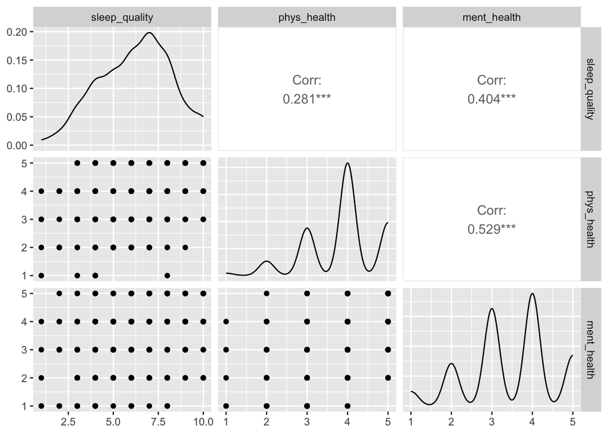

```r
data_small |>
  dplyr::select(sleep_quality, phys_health, ment_health) |>
  GGally::ggpairs()
```

# Ejercicio

## Ejercicio (15 minutos)

Vamos a explorar cuatro variables de hábitos de salud:

```r
pa_activity_level
eat_fast_food
caffeine_exam
alcohol_freq
```

### Instrucciones

1. Crea una base reducida llamada `data_exercise` con esas cuatro variables.
2. Revisa la estructura de la base con `glimpse()`.
3. Calcula descriptivos generales con `psych::describe()`.
4. Calcula una matriz de correlaciones entre las cuatro variables.
5. **Buscar**: Haz un gráfico de dispersión entre consumo de cafeína `caffeine_exam` y de alcohol `alcohol_freq`

## Solución 1. Crear una base reducida

```r
data_exercise <- data |>
  dplyr::select(
    pa_activity_level,
    eat_fast_food,
    caffeine_exam,
    alcohol_freq
  )
```

## Solución 2. Revisar la estructura

```r
dplyr::glimpse(data_exercise)
```

```
Rows: 590
Columns: 4
$ pa_activity_level <dbl+lbl> 0, 2, 1, 2, 2, 1, 1, 1, 1, 2, 2, 2, 2, 1, 2, 2, …
$ eat_fast_food     <dbl+lbl> 1, 0, 1, 2, 2, 1, 1, 1, 2, 2, 1, 2, 2, 1, 1, 2, …
$ caffeine_exam     <dbl+lbl> 6, 3, 7, 6, 6, 0, 7, 8, 6, 2, 0, 6, 6, 4, 3, 0, …
$ alcohol_freq      <dbl+lbl> 2, 1, 1, 1, 4, 1, 1, 5, 5, 1, 3, 3, 0, 1, 2, 4, …
```

### Preguntas

- ¿Cuántas variables tiene la base reducida?
- ¿Las variables son numéricas?
- ¿Hay valores perdidos?

## Solución 3. Descriptivos generales

```r
data_exercise |>
  psych::describe()
```

|  | vars | n | mean | sd | median | trimmed | mad | min | max | range | skew | kurtosis | se |
| --- | --- | --- | --- | --- | --- | --- | --- | --- | --- | --- | --- | --- | --- |
| pa_activity_level | 1 | 590 | 1.179661 | 0.5984643 | 1 | 1.224576 | 0.0000 | 0 | 2 | 2 | -0.08795511 | -0.4033747 | 0.02463838 |
| eat_fast_food | 2 | 590 | 1.481356 | 1.2162559 | 1 | 1.326271 | 1.4826 | 0 | 7 | 7 | 2.05553735 | 6.2324410 | 0.05007246 |
| caffeine_exam | 3 | 590 | 3.489831 | 2.6682561 | 3 | 3.427966 | 4.4478 | 0 | 8 | 8 | 0.14591469 | -1.4345819 | 0.10985037 |
| alcohol_freq | 4 | 590 | 1.484746 | 1.7015736 | 1 | 1.239407 | 1.4826 | 0 | 7 | 7 | 0.93534560 | -0.2941042 | 0.07005268 |

### Preguntas

- ¿Qué variable tiene la media más alta?
- ¿Qué variable tiene la desviación estándar más alta?
- ¿Qué variable tiene más valores perdidos?

## Solución 4. Matriz de correlaciones

```r
data_exercise |>
  cor(use = "pairwise.complete.obs") |>
  round(digits = 2)
```

```
                  pa_activity_level eat_fast_food caffeine_exam alcohol_freq
pa_activity_level              1.00          0.00          0.01         0.08
eat_fast_food                  0.00          1.00          0.04         0.06
caffeine_exam                  0.01          0.04          1.00         0.14
alcohol_freq                   0.08          0.06          0.14         1.00
```

### Preguntas

- ¿Qué dos variables tienen la correlación más alta?
- ¿La correlación es positiva o negativa?
- ¿Qué significa esa asociación?